# Reproducible Research: Peer Assessment 1

In the following report we will present analysis of the activity monitoring data made available for this assignment (dataset available [here](https://d396qusza40orc.cloudfront.net/repdata%2Fdata%2Factivity.zip)).

## Loading and preprocessing the data

1. Load the data (i.e. read.csv())

The csv is stored as *activity.csv* in the working directory.

```r
d <- read.csv("activity.csv")
```

## What is mean total number of steps taken per day?

For this part of the assignment, we ignore the missing values in the dataset.

1. Make a histogram of the total number of steps taken each day

We first find the daily sums to generate the histogram:

```r
sums_d <- tapply(d$steps, d$date, sum)
```

Following is the visualization:

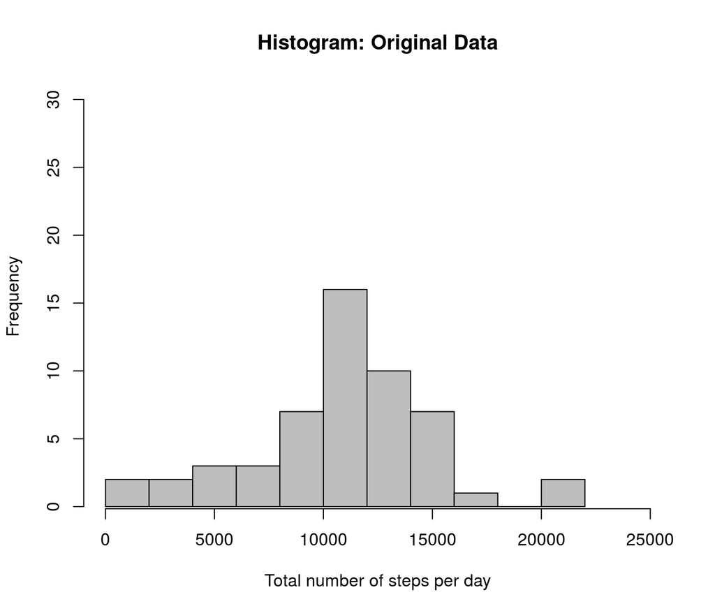

```r
hist(sums_d, xlab="Total number of steps per day",
     xlim=c(1, 25000), ylim=c(1, 30), breaks=10, col="grey",
     main="Histogram: Original Data")
```

```r
mean_d <- mean(sums_d, na.rm=T)
median_d <- median(sums_d, na.rm=T)
```

## What is the average daily activity pattern?

1. Make a time series plot with the 5-minute interval (x-axis) and the average number of steps taken, averaged across all days (y-axis)

We derive the interval averages:

```r
ints <- tapply(d$steps, d$interval, function(x) {mean(x, na.rm=T)})
```

The we use R’s built-in ts function to generate the time series graph:

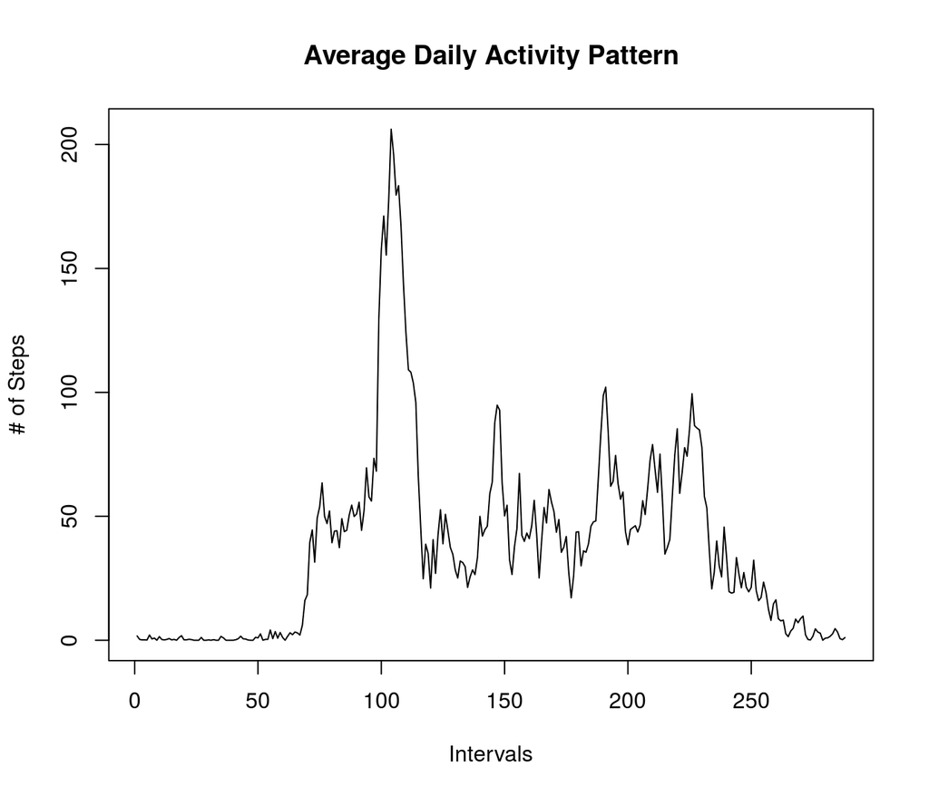

```r
ts.plot(ts(ints), xlab="Intervals", ylab="# of Steps", main="Average Daily Activity Pattern", type="l")
```

2. Which 5-minute interval, on average across all the days in the dataset, contains the maximum number of steps?

We simply find the max value of the *ints* array.

```r
which.max(ints)
```

```
## 835
## 104
```

## Imputing missing values

There are a number of days/intervals in the original dataset where there are missing values (coded as NA). The presence of missing days may introduce bias into some calculations or summaries of the data.

1. Calculate and report the total number of missing values in the dataset (i.e. the total number of rows with NAs)

```r
sum(is.na(d$steps))
```

```
## [1] 2304
```

2. Devise a strategy for filling in all of the missing values in the dataset. The strategy does not need to be sophisticated. For example, you could use the mean/median for that day, or the mean for that 5-minute interval, etc.

We are just going to substitute the missing values with zeros.

3. Create a new dataset that is equal to the original dataset but with the missing data filled in.

We create a new dataset *e*:

```r
e <- d
e$steps[is.na(e$steps)] <- 0
```

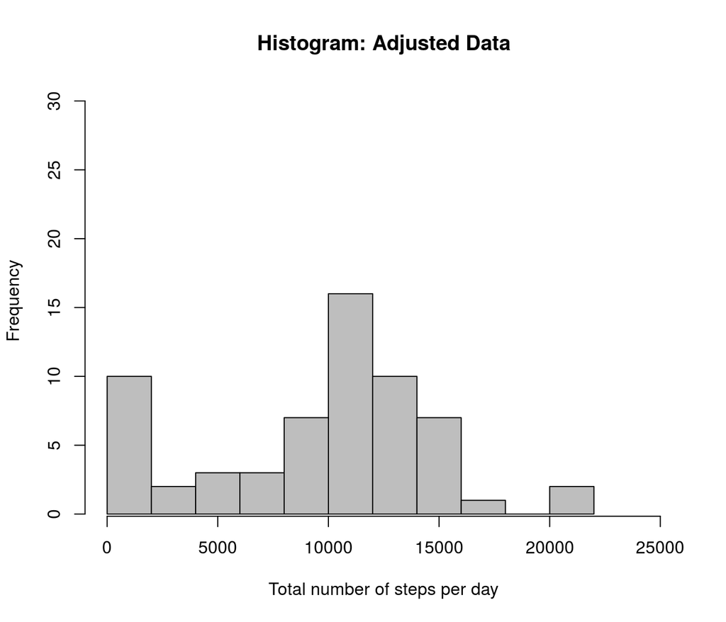

```r
#get statistics by date for new date
sums_e <- tapply(e$steps, e$date, sum)
mean_e <- mean(sums_e, na.rm=T)
median_e <- median(sums_e, na.rm=T)

#plot histogram new data
hist(sums_e, xlab="Total number of steps per day",
     xlim=c(1, 25000), ylim=c(1, 30), breaks=10, col="grey",
     main="Histogram: Adjusted Data")
```

## Are there differences in activity patterns between weekdays and weekends?

```r
Sys.setlocale("LC_TIME", "English")
```

```
## [1] ""
```

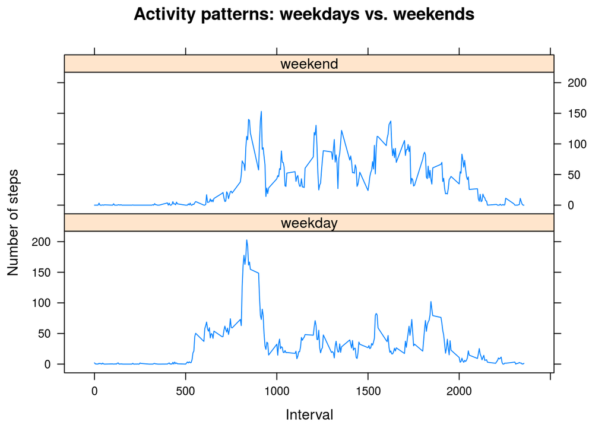

```r
wd <- e$date
e <- cbind(e, wd)
e$wd <- weekdays(as.Date(wd))
e[(e$wd == "Sunday") | (e$wd == "Saturday"), 4] <- "weekend"
e[(e$wd != "weekend"), 4] <- "weekday"

w1 <- tapply(e[(e$wd == "weekday"),1], e[(e$wd == "weekday"),3], mean)
w2 <- tapply(e[(e$wd == "weekend"),1], e[(e$wd == "weekend"),3], mean)

w1_df <- as.data.frame(as.vector(w1))
w1_df <- cbind(w1_df, e[1:288, 3])
w1_df <- cbind(w1_df, rep("weekday", each=288))
colnames(w1_df) <- c("steps", "interval", "wd")

w2_df <- as.data.frame(as.vector(w2))
w2_df <- cbind(w2_df, e[1:288, 3])
w2_df <- cbind(w2_df, rep("weekend", each=288))
colnames(w2_df) <- c("steps", "interval", "wd")

lat <- rbind(w1_df, w2_df)

library(lattice)
xyplot(steps~interval|wd, lat,
       main="Activity patterns: weekdays vs. weekends",
       xlab="Interval", ylab="Number of steps",
       layout=c(1,2), type="l")
```

Clearly, there are noticeable differences in the weekly patterns. E.g. on weekdays there is only 1 spike in the morning that stands out, while there are a number of similarly tall spikes throughout the middle of the day on weekends. However, while the weekend spikes occur more consistently, they are still shorter than the mid-morning weekday spike.